# F9_07_COMP_KONTR_NUM_GT_100K

Number of independent contractors who received more than $100,000 of compensation · Number report

## Overview

**Description**

Total number of independent contractors who received 100K+ from org

**Table**

`F9-P07-T00-DIR-TRUST-KEY` (one)

**Location code**

`F990-PC-PART-07-SECTION-B-LINE-02`, `F990-EZ-PART-06-LINE-51D`

**Family**

`F990-PC-PART-07-SECTION-B-LINE-02`

**Data type**

numeric (xsd: CountType, , IntegerNNType)

**Scope**

PZ

**Status**

unreviewed

5

xpaths mapped (4 observed)

2,367,550

filings with a value

2009–2024

tax years observed

1

open flags (0 errors)

## Flags

| Severity | Flag | Xpath | Detail |
| --- | --- | --- | --- |
| ⓘ info | `UNOBSERVED` | IRS990/Form990PartVIISectionB/NumberOfContractorsGT100K | never observed in TY2009-2024 filings |

## Xpaths

All mapped xpaths (under /Return/ReturnData or /Return/ReturnHeader), oldest first. Charts label each series by its xpath.

| Xpath | Form | First year | Last year | Versions | Filings | Repeats in |
| --- | --- | --- | --- | --- | --- | --- |
| IRS990/NumberOfContractorsGT100K | 990 | 2009 | 2012 | 18 | 333,538 | 0.0% |
| IRS990EZ/TotNumCntrctPdOver100KProfSer | 990-EZ | 2009 | 2012 | 15 | 3,247 | 0.0% |
| IRS990/CntrctRcvdGreaterThan100KCnt | 990 | 2013 | 2024 | 37 | 1,988,748 | 0.0% |
| IRS990EZ/CntrctRcvdGreaterThan100KCnt | 990-EZ | 2013 | 2024 | 36 | 42,017 | 0.0% |
| IRS990/Form990PartVIISectionB/NumberOfContractorsGT100K | 990 |  |  |  | 0 |  |

## Coverage

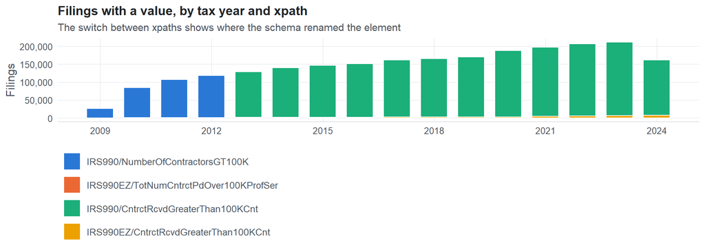

**Table view**

Table view: filings by tax year and series

| Tax year | IRS990/NumberOfContractorsGT100K | IRS990EZ/TotNumCntrctPdOver100KProfSer | IRS990/CntrctRcvdGreaterThan100KCnt | IRS990EZ/CntrctRcvdGreaterThan100KCnt |
| --- | --- | --- | --- | --- |
| 2009 | 26,435 | 210 | 0 | 0 |
| 2010 | 83,960 | 648 | 0 | 0 |
| 2011 | 106,061 | 992 | 0 | 0 |
| 2012 | 117,082 | 1,397 | 0 | 0 |
| 2013 | 0 | 0 | 127,255 | 1,559 |
| 2014 | 0 | 0 | 137,801 | 1,760 |
| 2015 | 0 | 0 | 145,074 | 1,842 |
| 2016 | 0 | 0 | 149,543 | 2,010 |
| 2017 | 0 | 0 | 159,440 | 2,574 |
| 2018 | 0 | 0 | 162,951 | 2,812 |
| 2019 | 0 | 0 | 167,839 | 2,468 |
| 2020 | 0 | 0 | 185,394 | 2,638 |
| 2021 | 0 | 0 | 193,250 | 4,461 |
| 2022 | 0 | 0 | 201,409 | 5,603 |
| 2023 | 0 | 0 | 204,388 | 7,037 |
| 2024 | 0 | 0 | 154,404 | 7,253 |

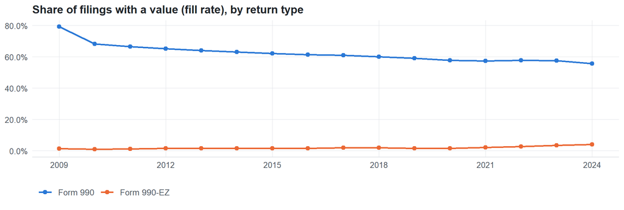

**Table view**

Table view: fill rate

| Tax year | Return type | Filings | All filings | Fill rate |
| --- | --- | --- | --- | --- |
| 2009 | Form 990 | 26,435 | 33,311 | 79.36% |
| 2009 | Form 990-EZ | 210 | 15,470 | 1.36% |
| 2010 | Form 990 | 83,960 | 123,025 | 68.25% |
| 2010 | Form 990-EZ | 648 | 63,326 | 1.02% |
| 2011 | Form 990 | 106,061 | 159,504 | 66.49% |
| 2011 | Form 990-EZ | 992 | 82,048 | 1.21% |
| 2012 | Form 990 | 117,082 | 179,688 | 65.16% |
| 2012 | Form 990-EZ | 1,397 | 93,750 | 1.49% |
| 2013 | Form 990 | 127,255 | 198,855 | 63.99% |
| 2013 | Form 990-EZ | 1,559 | 104,375 | 1.49% |
| 2014 | Form 990 | 137,801 | 218,619 | 63.03% |
| 2014 | Form 990-EZ | 1,760 | 116,417 | 1.51% |
| 2015 | Form 990 | 145,074 | 233,519 | 62.13% |
| 2015 | Form 990-EZ | 1,842 | 124,894 | 1.47% |
| 2016 | Form 990 | 149,543 | 243,903 | 61.31% |
| 2016 | Form 990-EZ | 2,010 | 130,484 | 1.54% |
| 2017 | Form 990 | 159,440 | 261,612 | 60.95% |
| 2017 | Form 990-EZ | 2,574 | 139,144 | 1.85% |
| 2018 | Form 990 | 162,951 | 271,442 | 60.03% |
| 2018 | Form 990-EZ | 2,812 | 149,384 | 1.88% |
| 2019 | Form 990 | 167,839 | 283,694 | 59.16% |
| 2019 | Form 990-EZ | 2,468 | 152,622 | 1.62% |
| 2020 | Form 990 | 185,394 | 320,342 | 57.87% |
| 2020 | Form 990-EZ | 2,638 | 169,864 | 1.55% |
| 2021 | Form 990 | 193,250 | 336,480 | 57.43% |
| 2021 | Form 990-EZ | 4,461 | 202,724 | 2.20% |
| 2022 | Form 990 | 201,409 | 349,055 | 57.70% |
| 2022 | Form 990-EZ | 5,603 | 206,130 | 2.72% |
| 2023 | Form 990 | 204,388 | 354,768 | 57.61% |
| 2023 | Form 990-EZ | 7,037 | 206,379 | 3.41% |
| 2024 | Form 990 | 154,404 | 277,298 | 55.68% |
| 2024 | Form 990-EZ | 7,253 | 178,867 | 4.05% |

## Values

| Result | Check | Detail |
| --- | --- | --- |
| ✓ pass | Values parse as numbers | 100.0% of values are numeric |
| ✓ pass | No sudden change in the median between adjacent years | largest change 1.1x (IRS990/NumberOfContractorsGT100K, 990, TY2010) |
| ✓ pass | Pooled xpaths are on the same scale (same return type) | largest ratio of medians between xpaths: 1.0x |
| ⚠ fail | One scale across xpaths (fraction vs percent) | IRS990/CntrctRcvdGreaterThan100KCnt: percent or small count; IRS990/NumberOfContractorsGT100K: percent or small count; IRS990EZ/CntrctRcvdGreaterThan100KCnt: fraction (0-1); IRS990EZ/TotNumCntrctPdOve… |

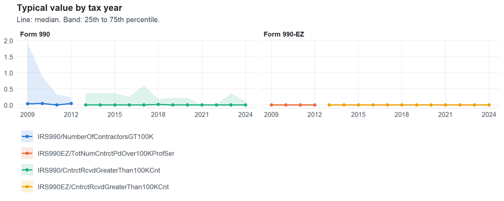

**Table view**

Table view: quartiles by tax year

| Series | Return | Tax year | Filings | P25 | Median | P75 |
| --- | --- | --- | --- | --- | --- | --- |
| IRS990/NumberOfContractorsGT100K | 990 | 2009 | 26,435 | 0.00 | 0.04 | 1.92 |
| IRS990/NumberOfContractorsGT100K | 990 | 2010 | 83,960 | 0.00 | 0.05 | 0.89 |
| IRS990/NumberOfContractorsGT100K | 990 | 2011 | 106,061 | 0 | 0 | 0.33 |
| IRS990/NumberOfContractorsGT100K | 990 | 2012 | 117,082 | 0.01 | 0.05 | 0.24 |
| IRS990EZ/TotNumCntrctPdOver100KProfSer | 990EZ | 2009 | 210 | 0 | 0 | 0 |
| IRS990EZ/TotNumCntrctPdOver100KProfSer | 990EZ | 2010 | 648 | 0.00 | 0.00 | 0.00 |
| IRS990EZ/TotNumCntrctPdOver100KProfSer | 990EZ | 2011 | 992 | 0 | 0 | 0 |
| IRS990EZ/TotNumCntrctPdOver100KProfSer | 990EZ | 2012 | 1,397 | 0.00 | 0.00 | 0.00 |
| IRS990/CntrctRcvdGreaterThan100KCnt | 990 | 2013 | 127,255 | 0 | 0 | 0.36 |
| IRS990/CntrctRcvdGreaterThan100KCnt | 990 | 2014 | 137,801 | 0 | 0 | 0.37 |
| IRS990/CntrctRcvdGreaterThan100KCnt | 990 | 2015 | 145,074 | 0 | 0 | 0.36 |
| IRS990/CntrctRcvdGreaterThan100KCnt | 990 | 2016 | 149,543 | 0 | 0 | 0.25 |
| IRS990/CntrctRcvdGreaterThan100KCnt | 990 | 2017 | 159,440 | 0 | 0 | 0.61 |
| IRS990/CntrctRcvdGreaterThan100KCnt | 990 | 2018 | 162,951 | 0 | 0.02 | 0.19 |
| IRS990/CntrctRcvdGreaterThan100KCnt | 990 | 2019 | 167,839 | 0 | 0 | 0.22 |
| IRS990/CntrctRcvdGreaterThan100KCnt | 990 | 2020 | 185,394 | 0 | 0 | 0.22 |
| IRS990/CntrctRcvdGreaterThan100KCnt | 990 | 2021 | 193,250 | 0 | 0 | 0 |
| IRS990/CntrctRcvdGreaterThan100KCnt | 990 | 2022 | 201,409 | 0 | 0 | 0 |
| IRS990/CntrctRcvdGreaterThan100KCnt | 990 | 2023 | 204,388 | 0 | 0 | 0.36 |
| IRS990/CntrctRcvdGreaterThan100KCnt | 990 | 2024 | 154,404 | 0 | 0 | 0.11 |
| IRS990EZ/CntrctRcvdGreaterThan100KCnt | 990EZ | 2013 | 1,559 | 0 | 0 | 0 |
| IRS990EZ/CntrctRcvdGreaterThan100KCnt | 990EZ | 2014 | 1,760 | 0 | 0 | 0 |
| IRS990EZ/CntrctRcvdGreaterThan100KCnt | 990EZ | 2015 | 1,842 | 0 | 0 | 0 |
| IRS990EZ/CntrctRcvdGreaterThan100KCnt | 990EZ | 2016 | 2,010 | 0 | 0 | 0 |
| IRS990EZ/CntrctRcvdGreaterThan100KCnt | 990EZ | 2017 | 2,574 | 0 | 0 | 0 |
| IRS990EZ/CntrctRcvdGreaterThan100KCnt | 990EZ | 2018 | 2,812 | 0.00 | 0.00 | 0.00 |
| IRS990EZ/CntrctRcvdGreaterThan100KCnt | 990EZ | 2019 | 2,468 | 0 | 0 | 0 |
| IRS990EZ/CntrctRcvdGreaterThan100KCnt | 990EZ | 2020 | 2,638 | 0 | 0 | 0 |
| IRS990EZ/CntrctRcvdGreaterThan100KCnt | 990EZ | 2021 | 4,461 | 0 | 0 | 0 |
| IRS990EZ/CntrctRcvdGreaterThan100KCnt | 990EZ | 2022 | 5,603 | 0.00 | 0.00 | 0.00 |
| IRS990EZ/CntrctRcvdGreaterThan100KCnt | 990EZ | 2023 | 7,037 | 0 | 0 | 0 |
| IRS990EZ/CntrctRcvdGreaterThan100KCnt | 990EZ | 2024 | 7,253 | 0 | 0 | 0 |

Summary by xpath and return type (all years)

| Series | Return | Filings | % numeric | % zero | % negative | Median (typical year) | P99 (typical year) |
| --- | --- | --- | --- | --- | --- | --- | --- |
| IRS990/NumberOfContractorsGT100K | 990 | 333,538 | 100 | 76.29 | 0 | 0 | 57 |
| IRS990EZ/TotNumCntrctPdOver100KProfSer | 990EZ | 3,247 | 100 | 98.89 | 0 | 0 | 0 |
| IRS990/CntrctRcvdGreaterThan100KCnt | 990 | 1,988,748 | 100 | 79.21 | 0 | 0 | 37 |
| IRS990EZ/CntrctRcvdGreaterThan100KCnt | 990EZ | 42,017 | 100 | 99.19 | 0 | 0 | 0 |

Scale of each xpath

| Series | P99 (typical year) | Implied scale |
| --- | --- | --- |
| IRS990/CntrctRcvdGreaterThan100KCnt | 37 | percent or small count |
| IRS990/NumberOfContractorsGT100K | 57 | percent or small count |
| IRS990EZ/CntrctRcvdGreaterThan100KCnt | 0 | fraction (0-1) |
| IRS990EZ/TotNumCntrctPdOver100KProfSer | 0 | fraction (0-1) |

## Examples

| Tax year | Return | Xpath | Organization | Value | Source |
| --- | --- | --- | --- | --- | --- |
| 2024 | 990 | IRS990/CntrctRcvdGreaterThan100KCnt | CHRISTIAN SHANE FONVILLE YOUTH | 0 | [XML](https://gt990datalake-rawdata.s3.amazonaws.com/EfileData/XmlFiles/202511059349301411_public.xml) |
| 2024 | 990EZ | IRS990EZ/CntrctRcvdGreaterThan100KCnt | Releve Dance Company Booster Inc | 0 | [XML](https://gt990datalake-rawdata.s3.amazonaws.com/EfileData/XmlFiles/202520639349200807_public.xml) |
| 2023 | 990 | IRS990/CntrctRcvdGreaterThan100KCnt | ARIZONA YOUTH PARTNERSHIP | 0 | [XML](https://gt990datalake-rawdata.s3.amazonaws.com/EfileData/XmlFiles/202510809349301201_public.xml) |
| 2023 | 990EZ | IRS990EZ/CntrctRcvdGreaterThan100KCnt | Gospel of Christ Christian Fellowship dba Kingdom Life Fellowship Church | 0 | [XML](https://gt990datalake-rawdata.s3.amazonaws.com/EfileData/XmlFiles/202430319349200623_public.xml) |
| 2022 | 990 | IRS990/CntrctRcvdGreaterThan100KCnt | COLUMBIA VALLEY HOUSING ASSOCIATION DBA | 0 | [XML](https://gt990datalake-rawdata.s3.amazonaws.com/EfileData/XmlFiles/202313189349316186_public.xml) |
| 2022 | 990EZ | IRS990EZ/CntrctRcvdGreaterThan100KCnt | PTA FLORIDA CONGRESS | 0 | [XML](https://gt990datalake-rawdata.s3.amazonaws.com/EfileData/XmlFiles/202430999349201633_public.xml) |
| 2021 | 990 | IRS990/CntrctRcvdGreaterThan100KCnt | CAMP JOHN MARC FOUNDATION INC | 0 | [XML](https://gt990datalake-rawdata.s3.amazonaws.com/EfileData/XmlFiles/202241039349300339_public.xml) |
| 2021 | 990EZ | IRS990EZ/CntrctRcvdGreaterThan100KCnt | ARKANSAS INTERFAITH POWER AND LIGHT | 0 | [XML](https://gt990datalake-rawdata.s3.amazonaws.com/EfileData/XmlFiles/202201739349200710_public.xml) |
| 2020 | 990 | IRS990/CntrctRcvdGreaterThan100KCnt | SOCIAL JUSTICE PUBLIC CHARTER SCHOOL | 0 | [XML](https://gt990datalake-rawdata.s3.amazonaws.com/EfileData/XmlFiles/202201309349304660_public.xml) |
| 2020 | 990EZ | IRS990EZ/CntrctRcvdGreaterThan100KCnt | TUALATIN HILLS DIVE CLUB | 0 | [XML](https://gt990datalake-rawdata.s3.amazonaws.com/EfileData/XmlFiles/202201089349201870_public.xml) |
| 2019 | 990 | IRS990/CntrctRcvdGreaterThan100KCnt | Green Woods Club Inc | 0 | [XML](https://gt990datalake-rawdata.s3.amazonaws.com/EfileData/XmlFiles/202142149349300449_public.xml) |
| 2019 | 990EZ | IRS990EZ/CntrctRcvdGreaterThan100KCnt | CAPS OF LOVE INC | 0 | [XML](https://gt990datalake-rawdata.s3.amazonaws.com/EfileData/XmlFiles/202031159349201018_public.xml) |

## Reviewer checklist

- The definition matches the form line and instructions for every xpath’s schema years.
- Every xpath pooled here measures the same thing on the 990 and 990-EZ (close enough for analysis).
- The coverage chart has no unexplained gaps or jumps between tax years.
- Each open flag is fixed, or accepted with a note in validation_log.csv.
- Counts are whole numbers and plausible (e.g. employees, volunteers, voting members).
- Ratios and percentages use one scale (0-1 or 0-100) across all xpaths and years.
- Units match the form line (hours per week, number of states, percent of support).

Record the review as a row in `inst/extdata/src/validation_log.csv` (variable_name, reviewer, date, status, note). Evidence built 2026-09-23 17:09:04 MST from the ef2 DuckDB builds (tax years 2009–2024).